# market Basket Analysis

Gerhard Westerbeek

27-11-2019

#Defining the problem Perform a market basket analysis to help Blackwell’s board of directors to better understand the clientele that Electronidex is currently serving and if Electronidex would be an optimal acquisition.

Our work in that task would be: 1. Verify if there are any interesting patterns or item relationships within Electronidex’s transactions? 2. Define if Blackwell benefit from selling any of Electronidex’s items? 3. In your opinion, should Blackwell acquire Electronidex? 4. If Blackwell does acquire Electronidex, do you have any recommendations for Blackwell? (Ex: cross-selling items, sale promotions, should they remove items, etc.)

#Import the data

```r
Dataset <- read.transactions("ElectronidexTransactions2017.csv",
format = "basket", sep=",", rm.duplicates=TRUE)
```

```
## distribution of transactions with duplicates:
## items
##   1   2
## 191  10
```

# First exploration transactional data

The transaction data set is composed of 9835 transactions involving 125 distinct products. In below graph the top 15 of the most frequently sold items of one month is presented. The top 15 most frequent sold products consitst out of 9 computers (laptops included).

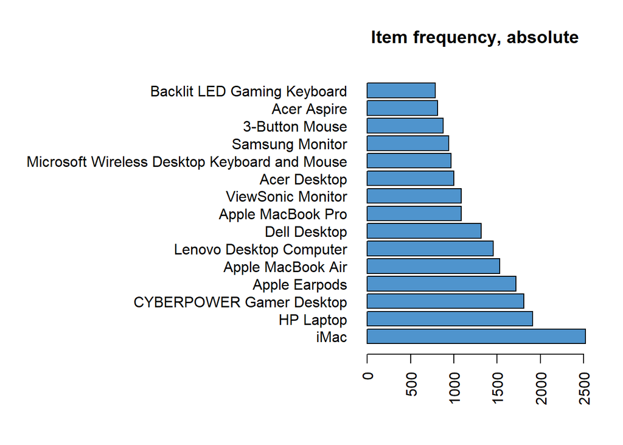

```r
itemFrequencyPlot(Dataset,
                  type="absolute",
                  topN=15, # can be changed to the number of interest
                  horiz=TRUE,
                  col='steelblue3',
                  xlab='',
                  main='Item frequency, absolute')
```

#Compare dataset Blackwell and Electronidex In order to make a thorough comparison between the products of Blackwell and Electronidex, a categorization of the items of Electronidex has been created based on the available item list. The transaction data set is composed of 9835 transactions involving 18 categories. In below graph the frequency of transactions by category is presented.The top 3 consists out of “Desktops”, “Laptops” and “Monitors”.

```
## * `` -> ...1
## * `` -> ...2
```

```
## transactions as itemMatrix in sparse format with
##  9835 rows (elements/itemsets/transactions) and
##  18 columns (items) and a density of 0.1886855
##
## most frequent items:
##  desktop   laptop  monitor    mouse keyboard  (Other)
##     5704     5256     3866     2699     2513    13365
##
## element (itemset/transaction) length distribution:
## sizes
##    0    1    2    3    4    5    6    7    8    9   10   11   12   13   14
##    2 2369 1924 1583 1259  981  690  470  248  149   75   46   28    7    2
##   15
##    2
##
##    Min. 1st Qu.  Median    Mean 3rd Qu.    Max.
##   0.000   2.000   3.000   3.396   5.000  15.000
##
## includes extended item information - examples:
##          labels    categories
## 1    accesories    accesories
## 2 actvheadphone actvheadphone
## 3 compheadphone compheadphone
```

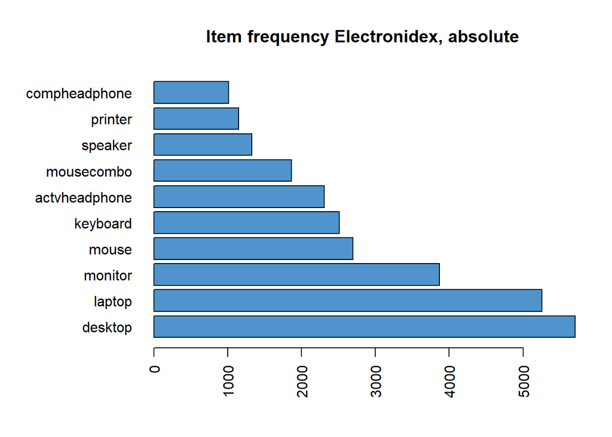

```r
itemFrequencyPlot(cat_trans,
                  type="absolute",
                  topN=10,
                  horiz=TRUE,
                  col='steelblue3',
                  xlab='',
                  main='Item frequency Electronidex, absolute')
```

# Item Frequency Blackwell

In below graph the frequency of transactions of Blackwell by category is presented. The top 3 consists out of “Game Console”, “Printers” and “Smartphones”.

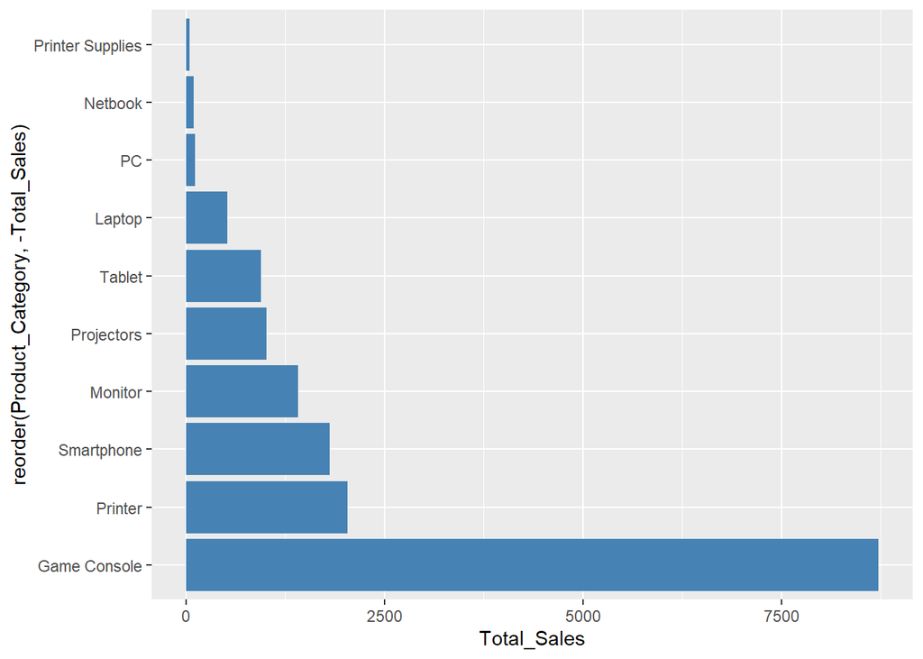

```r
Sales_Blackwell <- read_excel("Sales Blackwell.xlsx",
                              sheet = "Existing Product List")
Sum_Blackwell <- Sales_Blackwell %>% group_by(Product_Category)%>%
        summarize(Total_Sales = sum(Sales_Volume))

ggplot(Sum_Blackwell, aes(x = reorder(Product_Category, -Total_Sales),
                y = Total_Sales)) +
  geom_col(fill = "steelblue") + coord_flip ()
```

# apriori algorithm

The apriori algorithm function has been run with the following parameters:  Support: 0.01 – meaning that we are looking for rules explaining at least 98 transactions.  Confidence: 0.5 – reasonable value for the accuracy of our rules.  Max Length: Not set  Min Length: Not set

```r
RulesName<- apriori (Dataset, parameter = list(supp = 0.01,
                                                conf = 0.5))
```

```
## Apriori
##
## Parameter specification:
##  confidence minval smax arem  aval originalSupport maxtime support minlen
##         0.5    0.1    1 none FALSE            TRUE       5    0.01      1
##  maxlen target   ext
##      10  rules FALSE
##
## Algorithmic control:
##  filter tree heap memopt load sort verbose
##     0.1 TRUE TRUE  FALSE TRUE    2    TRUE
##
## Absolute minimum support count: 98
##
## set item appearances ...[0 item(s)] done [0.00s].
## set transactions ...[125 item(s), 9835 transaction(s)] done [0.00s].
## sorting and recoding items ... [82 item(s)] done [0.00s].
## creating transaction tree ... done [0.00s].
## checking subsets of size 1 2 3 4 done [0.00s].
## writing ... [19 rule(s)] done [0.00s].
## creating S4 object  ... done [0.00s].
```

```r
plot(RulesName, method = "graph", engine = "htmlwidget")
```

[interactive chart not shown]

#Findings The rules were selected after inspecting the relevance of support, confidence and lift (in that order). This meant that we looked for rules relevant to plenty of transactions, high accuracy and lift greater or equal to one. After inspecting the most meaningful rules in the business product type subset, we can draw the following conclusion:

1. A strong rule that appears is that the combination {HP Laptop,Lenovo Desktop Computer} often implies the purchase of an {iMac} ;
2. In a lot of transactions iMac is at the RHS, as a consequence of purchasing combination of Desktops and Monitors.

The apriori algorithm function has been run with the following parameters:  Support: 0.01 – meaning that we are looking for rules explaining at least 98 transactions.  Confidence: 0.4 – reasonable value for the accuracy of our rules.  Max Length: Not set  Min Length: Not set

```r
RulesNameSub<- apriori(Dataset, parameter = list(supp = 0.01,
                                                        conf = 0.4))
```

```
## Apriori
##
## Parameter specification:
##  confidence minval smax arem  aval originalSupport maxtime support minlen
##         0.4    0.1    1 none FALSE            TRUE       5    0.01      1
##  maxlen target   ext
##      10  rules FALSE
##
## Algorithmic control:
##  filter tree heap memopt load sort verbose
##     0.1 TRUE TRUE  FALSE TRUE    2    TRUE
##
## Absolute minimum support count: 98
##
## set item appearances ...[0 item(s)] done [0.00s].
## set transactions ...[125 item(s), 9835 transaction(s)] done [0.00s].
## sorting and recoding items ... [82 item(s)] done [0.00s].
## creating transaction tree ... done [0.00s].
## checking subsets of size 1 2 3 4 done [0.00s].
## writing ... [70 rule(s)] done [0.00s].
## creating S4 object  ... done [0.00s].
```

```r
inspect(RulesNameSub)
```

```
##      lhs                                                        rhs            support confidence     lift count
## [1]  {Logitech MK550 Wireless Wave Keyboard and Mouse Combo} => {iMac}      0.01006609  0.4107884 1.603852    99
## [2]  {Alienware Laptop}                                      => {iMac}      0.01159126  0.4145455 1.618521   114
## [3]  {HDMI Cable 6ft}                                        => {iMac}      0.01148958  0.4414062 1.723394   113
## [4]  {Panasonic In-Ear Headphone}                            => {iMac}      0.01077783  0.4326531 1.689219   106
## [5]  {Eluktronics Pro Gaming Laptop}                         => {HP Laptop} 0.01443823  0.4045584 2.084249   142
## [6]  {Eluktronics Pro Gaming Laptop}                         => {iMac}      0.01576004  0.4415954 1.724133   155
## [7]  {Intel Desktop}                                         => {iMac}      0.01647178  0.4153846 1.621797   162
## [8]  {AOC Monitor}                                           => {iMac}      0.01718353  0.4082126 1.593795   169
## [9]  {HP Wireless Mouse}                                     => {HP Laptop} 0.01789527  0.4112150 2.118543   176
## [10] {HP Wireless Mouse}                                     => {iMac}      0.01779359  0.4088785 1.596395   175
## [11] {Computer Game}                                         => {HP Laptop} 0.01799695  0.4285714 2.207962   177
## [12] {Epson Printer}                                         => {iMac}      0.02043721  0.4249471 1.659133   201
## [13] {ASUS Chromebook}                                       => {iMac}      0.02135231  0.4069767 1.588970   210
## [14] {ASUS 2 Monitor}                                        => {iMac}      0.02806304  0.4867725 1.900519   276
## [15] {Belkin Mouse Pad}                                      => {iMac}      0.02419929  0.4131944 1.613246   238
## [16] {ASUS Monitor}                                          => {iMac}      0.02765633  0.4990826 1.948582   272
## [17] {Microsoft Office Home and Student 2016}                => {iMac}      0.03101169  0.4663609 1.820825   305
## [18] {Apple Magic Keyboard}                                  => {HP Laptop} 0.02887646  0.4028369 2.075380   284
## [19] {Apple Magic Keyboard}                                  => {iMac}      0.03233350  0.4510638 1.761101   318
## [20] {ViewSonic Monitor}                                     => {HP Laptop} 0.04799187  0.4350230 2.241200   472
## [21] {ViewSonic Monitor}                                     => {iMac}      0.04941535  0.4479263 1.748851   486
## [22] {Dell Desktop}                                          => {iMac}      0.05460092  0.4074355 1.590762   537
## [23] {HP Laptop,
##       LG Monitor}                                            => {iMac}      0.01026945  0.4741784 1.851348   101
## [24] {iMac,
##       LG Monitor}                                            => {HP Laptop} 0.01026945  0.4611872 2.375996   101
## [25] {ASUS 2 Monitor,
##       Lenovo Desktop Computer}                               => {iMac}      0.01087951  0.5911602 2.308083   107
## [26] {ASUS 2 Monitor,
##       HP Laptop}                                             => {iMac}      0.01108287  0.5828877 2.275784   109
## [27] {ASUS Monitor,
##       HP Laptop}                                             => {iMac}      0.01179461  0.5829146 2.275889   116
## [28] {ASUS Monitor,
##       iMac}                                                  => {HP Laptop} 0.01179461  0.4264706 2.197139   116
## [29] {HP Laptop,
##       Microsoft Office Home and Student 2016}                => {iMac}      0.01291307  0.5521739 2.155868   127
## [30] {iMac,
##       Microsoft Office Home and Student 2016}                => {HP Laptop} 0.01291307  0.4163934 2.145222   127
## [31] {HP Laptop,
```

[output cut: 64 more lines]

```
##       Dell Desktop}                                          => {iMac}      0.01362481  0.4481605 1.749765   134
## [64] {Dell Desktop,
##       Lenovo Desktop Computer}                               => {HP Laptop} 0.01504830  0.4099723 2.112141   148
## [65] {Dell Desktop,
##       Lenovo Desktop Computer}                               => {iMac}      0.01860702  0.5069252 1.979202   183
## [66] {Dell Desktop,
##       HP Laptop}                                             => {iMac}      0.02226741  0.4954751 1.934497   219
## [67] {Dell Desktop,
##       iMac}                                                  => {HP Laptop} 0.02226741  0.4078212 2.101059   219
## [68] {CYBERPOWER Gamer Desktop,
##       Lenovo Desktop Computer}                               => {iMac}      0.01606507  0.4463277 1.742609   158
## [69] {CYBERPOWER Gamer Desktop,
##       HP Laptop}                                             => {iMac}      0.01799695  0.4224344 1.649322   177
## [70] {HP Laptop,
##       Lenovo Desktop Computer}                               => {iMac}      0.02308083  0.5000000 1.952164   227
```

```r
inspect(RulesNameSub)
```

```
##      lhs                                                        rhs            support confidence     lift count
## [1]  {Logitech MK550 Wireless Wave Keyboard and Mouse Combo} => {iMac}      0.01006609  0.4107884 1.603852    99
## [2]  {Alienware Laptop}                                      => {iMac}      0.01159126  0.4145455 1.618521   114
## [3]  {HDMI Cable 6ft}                                        => {iMac}      0.01148958  0.4414062 1.723394   113
## [4]  {Panasonic In-Ear Headphone}                            => {iMac}      0.01077783  0.4326531 1.689219   106
## [5]  {Eluktronics Pro Gaming Laptop}                         => {HP Laptop} 0.01443823  0.4045584 2.084249   142
## [6]  {Eluktronics Pro Gaming Laptop}                         => {iMac}      0.01576004  0.4415954 1.724133   155
## [7]  {Intel Desktop}                                         => {iMac}      0.01647178  0.4153846 1.621797   162
## [8]  {AOC Monitor}                                           => {iMac}      0.01718353  0.4082126 1.593795   169
## [9]  {HP Wireless Mouse}                                     => {HP Laptop} 0.01789527  0.4112150 2.118543   176
## [10] {HP Wireless Mouse}                                     => {iMac}      0.01779359  0.4088785 1.596395   175
## [11] {Computer Game}                                         => {HP Laptop} 0.01799695  0.4285714 2.207962   177
## [12] {Epson Printer}                                         => {iMac}      0.02043721  0.4249471 1.659133   201
## [13] {ASUS Chromebook}                                       => {iMac}      0.02135231  0.4069767 1.588970   210
## [14] {ASUS 2 Monitor}                                        => {iMac}      0.02806304  0.4867725 1.900519   276
## [15] {Belkin Mouse Pad}                                      => {iMac}      0.02419929  0.4131944 1.613246   238
## [16] {ASUS Monitor}                                          => {iMac}      0.02765633  0.4990826 1.948582   272
## [17] {Microsoft Office Home and Student 2016}                => {iMac}      0.03101169  0.4663609 1.820825   305
## [18] {Apple Magic Keyboard}                                  => {HP Laptop} 0.02887646  0.4028369 2.075380   284
## [19] {Apple Magic Keyboard}                                  => {iMac}      0.03233350  0.4510638 1.761101   318
## [20] {ViewSonic Monitor}                                     => {HP Laptop} 0.04799187  0.4350230 2.241200   472
## [21] {ViewSonic Monitor}                                     => {iMac}      0.04941535  0.4479263 1.748851   486
## [22] {Dell Desktop}                                          => {iMac}      0.05460092  0.4074355 1.590762   537
## [23] {HP Laptop,
##       LG Monitor}                                            => {iMac}      0.01026945  0.4741784 1.851348   101
## [24] {iMac,
##       LG Monitor}                                            => {HP Laptop} 0.01026945  0.4611872 2.375996   101
## [25] {ASUS 2 Monitor,
##       Lenovo Desktop Computer}                               => {iMac}      0.01087951  0.5911602 2.308083   107
## [26] {ASUS 2 Monitor,
##       HP Laptop}                                             => {iMac}      0.01108287  0.5828877 2.275784   109
## [27] {ASUS Monitor,
##       HP Laptop}                                             => {iMac}      0.01179461  0.5829146 2.275889   116
## [28] {ASUS Monitor,
##       iMac}                                                  => {HP Laptop} 0.01179461  0.4264706 2.197139   116
## [29] {HP Laptop,
##       Microsoft Office Home and Student 2016}                => {iMac}      0.01291307  0.5521739 2.155868   127
## [30] {iMac,
##       Microsoft Office Home and Student 2016}                => {HP Laptop} 0.01291307  0.4163934 2.145222   127
## [31] {HP Laptop,
```

[output cut: 64 more lines]

```
##       Dell Desktop}                                          => {iMac}      0.01362481  0.4481605 1.749765   134
## [64] {Dell Desktop,
##       Lenovo Desktop Computer}                               => {HP Laptop} 0.01504830  0.4099723 2.112141   148
## [65] {Dell Desktop,
##       Lenovo Desktop Computer}                               => {iMac}      0.01860702  0.5069252 1.979202   183
## [66] {Dell Desktop,
##       HP Laptop}                                             => {iMac}      0.02226741  0.4954751 1.934497   219
## [67] {Dell Desktop,
##       iMac}                                                  => {HP Laptop} 0.02226741  0.4078212 2.101059   219
## [68] {CYBERPOWER Gamer Desktop,
##       Lenovo Desktop Computer}                               => {iMac}      0.01606507  0.4463277 1.742609   158
## [69] {CYBERPOWER Gamer Desktop,
##       HP Laptop}                                             => {iMac}      0.01799695  0.4224344 1.649322   177
## [70] {HP Laptop,
##       Lenovo Desktop Computer}                               => {iMac}      0.02308083  0.5000000 1.952164   227
```

```r
subset <- subset(RulesNameSub,
                 subset = lhs %in% c("Lenovo Desktop Computer",
                                     "Acer Aspire",
                                     "Acer Desktop",
                                     "ASUS Chromebook",
                                     "Alienware Laptop",
                                     "Apple MacBook Pro",
                                     "Apple MacBook Air",
                                     # "ASUS Chromebook"))
                                     "CYBERPOWER Gamer Desktop",
                                     "Dell Desktop",
                                     "Dell Laptop",
                                     "HP Desktop",
                                     "HP Laptop",
                                     "HP Notebook Touchscreen Laptop PC",
                                     "iMac",
                                     "LG Touchscreen Laptop"))

library(arules)
library(arulesViz)

plot(subset, method = "graph", engine = "htmlwidget")
```

[interactive chart not shown]

```r
library(arules)
library(arulesViz)

temp_rules <- readRDS("subset_rules.rds")
plot(subset, method = "graph", engine = "htmlwidget")
```

[interactive chart not shown]